[figure not shown]

PS(diag)-24

Diagnostic Procedure with Diagnostic Trouble Code (DTC)

POWER ASSISTED SYSTEM (POWER STEERING) (DIAGNOSTICS)

12.Diagnostic Procedure with Diagnostic Trouble Code (DTC)

A: DTC C2511 TORQUE SENSOR FAILURE 1 (MAIN)

DTC DETECTING CONDITION:

When torque sensor main output voltage failure is detected after the ignition switch is to ON.

TROUBLE SYMPTOM:

• The steering wheel operation feels heavy.

• STEERING warning light illuminates.

WIRING DIAGRAM:

Electric power steering system <Ref. to WI-159, Electric Power Steering System.>

Step Check Yes No

1 CHECK TORQUE SENSOR SIGNAL.

1) Display the current data of the power steer-

ing control module using the Subaru Select

Monitor.

2) Check the voltage of «Torque sensor main

output», «Torque sensor sub output» and

«Torque sensor power supply voltage».

Are the voltage of «Torque sen-

sor main output» and «Torque

sensor sub output» 2.5±0.1 V?

Is the voltage of «Torque sen-

sor power supply voltage»

5±0.3 V?

Check for poor

contact of the con-

nector, and check

the conditions

again. If the condi-

tion recur, go to the

next step. Go to

step 2.

If it does not recur,

complete the

inspection.

Go to step 2.

2 CHECK HARNESS.

1) Turn the ignition switch to OFF.

2) Disconnect the connectors (B450, B451).

3) Using a tester and test harness, check the

internal resistance of the harness terminals.

Connector & terminal

(B450) No. 4 — (B451) No. 2:

(B450) No. 5 — (B451) No. 1:

(B450) No. 9 — (B451) No. 5:

(B450) No. 10 — (B451) No. 3:

Is the resistance less than 10

Ω?

Go to step 3. Repair or replace

the harness.

A:

PS3

132

45

9

10

78

5

6

34

2

1

B450

3

5

1

2

4

A10

A9

A5

A4

A3

B450

PS-01706

TORQUE SENSOR

POWER STEERING CM

[figure not shown]

PS(diag)-25

Diagnostic Procedure with Diagnostic Trouble Code (DTC)

POWER ASSISTED SYSTEM (POWER STEERING) (DIAGNOSTICS)

B: DTC C2512 TORQUE SENSOR FAILURE 2 (SUB)

DTC DETECTING CONDITION:

When torque sensor sub output voltage failure is detected after the ignition switch is to ON.

NOTE:

For the diagnostic procedures, refer to “DTC 2511 TORQUE SENSOR FAILURE 1 (MAIN)”. <Ref. to PS(di-

ag)-24, DTC C2511 TORQUE SENSOR FAILURE 1 (MAIN), Diagnostic Procedure with Diagnostic Trouble

Code (DTC).>

C: DTC C2513 TORQUE SENSOR FAILURE 3 (MUCH TOLERANCE)

DTC DETECTING CONDITION:

When torque sensor main/sub output voltage failure is detected after the ignition switch is to ON.

NOTE:

For the diagnostic procedures, refer to “DTC 2511 TORQUE SENSOR FAILURE 1 (MAIN)”. <Ref. to PS(di-

ag)-24, DTC C2511 TORQUE SENSOR FAILURE 1 (MAIN), Diagnostic Procedure with Diagnostic Trouble

Code (DTC).>

1) Connect the connector (B450) to the power

steering control module.

2) Turn the ignition switch to ON.

3) Short the circuit between connector (B451)

terminals.

Terminals

No. 3 — No. 1:

No. 3 — No. 2:

4) Using the Subaru Select Monitor, check the

voltages of «Torque sensor main output» and

«Torque sensor sub output».

Is the voltage of «Torque sen-

sor main output» 2.5±0.3 V, and

the voltage of «Torque sensor

sub output» 0±0.1 V before the

circuit is shorted?

Are the voltages of «Torque

sensor main output» and

«Torque sensor sub output»

after you short the circuit 5±0.3

V?

Replace the steer-

ing gearbox. <Ref.

to PS-56, Electric

Power Steering

Gearbox.>

Replace the power

steering control

module. <Ref. to

PS-84, Power

Steering Control

Module.>

Step Check Yes No

[figure not shown]

PS(diag)-26

Diagnostic Procedure with Diagnostic Trouble Code (DTC)

POWER ASSISTED SYSTEM (POWER STEERING) (DIAGNOSTICS)

D: DTC C2514 TORQUE SENSOR POWER SUPPLY FAILURE

DTC DETECTING CONDITION:

When torque sensor power supply voltage failure is detected after the ignition switch is to ON.

TROUBLE SYMPTOM:

• The steering wheel operation feels heavy.

• STEERING warning light illuminates.

WIRING DIAGRAM:

Electric power steering system <Ref. to WI-159, Electric Power Steering System.>

Step Check Yes No

1 CHECK TORQUE SENSOR SIGNAL.

1) Display the current data of the power steer-

ing control module using the Subaru Select

Monitor.

2) Check the voltage of «Torque sensor main

output», «Torque sensor sub output» and

«Torque sensor power supply voltage».

Are the voltage of «Torque sen-

sor main output» and «Torque

sensor sub output» 2.5±0.1 V?

Is the voltage of «Torque sen-

sor power supply voltage»

5±0.3 V?

Check for poor

contact of the con-

nector, and check

the conditions

again. If the condi-

tion recur, go to the

next step. Go to

step 2.

If it does not recur,

complete the

inspection.

Go to step 2.

2 CHECK HARNESS.

1) Turn the ignition switch to OFF.

2) Disconnect the connector (B451).

3) Using a tester and test harness, check the

internal resistance of the harness terminals.

Connector & terminal

(B450) No. 4 — (B451) No. 2:

(B450) No. 5 — (B451) No. 1:

(B450) No. 9 — (B451) No. 5:

(B450) No. 10 — (B451) No. 3:

Is the resistance less than 10

Ω?

Replace the power

steering control

module. <Ref. to

PS-84, Power

Steering Control

Module.>

Repair or replace

the harness.

A:

PS3

132

45

9

10

78

5

6

34

2

1

B450

3

5

1

2

4

A10

A9

A5

A4

A3

B450

PS-01706

TORQUE SENSOR

POWER STEERING CM

[figure not shown]

PS(diag)-27

Diagnostic Procedure with Diagnostic Trouble Code (DTC)

POWER ASSISTED SYSTEM (POWER STEERING) (DIAGNOSTICS)

E: DTC C2521 MOTOR FAILURE 1 (MOTOR)

DTC DETECTING CONDITION:

• When motor driving element malfunction is detected after assist starts with 500 rpm engine speed recep-

tion.

• When motor current failure is detected after assist starts with 500 rpm engine speed reception.

• When motor voltage failure is detected after assist starts with 500 rpm engine speed reception.

TROUBLE SYMPTOM:

• The steering wheel operation feels heavy.

• STEERING warning light illuminates.

WIRING DIAGRAM:

Electric power steering system <Ref. to WI-159, Electric Power Steering System.>

Step Check Yes No

1 CHECK HARNESS AND CONNECTOR.

Check the connection status of the power steer-

ing control module and motor harness (PS2).

Are the harness and connector

firmly installed?

Go to step 2. Check the connec-

tion of connectors/

terminals/har-

nesses and per-

form inspection

again.

2 CHECK MOTOR UNIT.

1) Turn the ignition switch to OFF.

2) Disconnect the connector (PS2) from the

power steering control module.

3) Use a tester to check for continuity in the

motor.

Connector & terminal

(PS2) No. 1 — No. 2:

(PS2) No. 1 — No. 3:

(PS2) No. 2 — No. 3:

Is there continuity? Go to step 3. Replace the steer-

ing gearbox. <Ref.

to PS-56, Electric

Power Steering

Gearbox.>

3 CHECK MOTOR INSULATION.

Use a tester to check for short circuits in the

motor.

Connector & terminal

(PS2) No. 1 — Steering gearbox body:

(PS2) No. 2 — Steering gearbox body:

(PS2) No. 3 — Steering gearbox body:

Is the resistance 1 MΩ or

more?

Replace the power

steering control

module. <Ref. to

PS-84, Power

Steering Control

Module.>

Replace the steer-

ing gearbox. <Ref.

to PS-56, Electric

Power Steering

Gearbox.>

PS4

1

PS2

D:

312

1

D3

D2

D1

PS4

PS2

PS-01707

POWER STEERING CM

MOTOR

POWER STEERING

BRACKET GROUND

[figure not shown]

PS(diag)-28

Diagnostic Procedure with Diagnostic Trouble Code (DTC)

POWER ASSISTED SYSTEM (POWER STEERING) (DIAGNOSTICS)

F: DTC C2522 MOTOR FAILURE 2 (ANGLE ABNORMAL)

DTC DETECTING CONDITION:

When resolver signal output voltage failure is detected after assist starts with 500 rpm engine speed recep-

tion.

TROUBLE SYMPTOM:

• The steering wheel operation feels heavy.

• STEERING warning light illuminates.

WIRING DIAGRAM:

Electric power steering system <Ref. to WI-159, Electric Power Steering System.>

Step Check Yes No

1 CHECK HARNESS AND CONNECTOR.

Check the connection status of the power steer-

ing control module and resolver sensor harness

(PS1).

Are the harness and connector

firmly installed?

Go to step 2. Check the connec-

tion of connectors/

terminals/har-

nesses and per-

form inspection

again.

2 PERFORM UNIT CHECK OF RESOLVER

SENSOR.

1) Turn the ignition switch to OFF.

2) Disconnect the connector (PS1) from the

power steering control module.

3) Use a tester to check for continuity in the

resolver sensor.

Connector & terminal

(PS1) No. 1 — No. 2 :

(PS1) No. 3 — No. 4 :

(PS1) No. 5 — No. 6 :

Is there continuity? Go to step 3. Replace the steer-

ing gearbox. <Ref.

to PS-56, Electric

Power Steering

Gearbox.>

3 CHECK RESOLVER SENSOR INSULATION.

Using a tester, check for short circuits in the

resolver sensor.

Connector & terminal

(PS1) No. 1 — Steering gearbox body:

(PS1) No. 2 — Steering gearbox body:

(PS1) No. 3 — Steering gearbox body:

(PS1) No. 4 — Steering gearbox body:

(PS1) No. 5 — Steering gearbox body:

(PS1) No. 6 — Steering gearbox body:

Is the resistance 1 MΩ or

more?

Replace the power

steering control

module. <Ref. to

PS-84, Power

Steering Control

Module.>

Replace the steer-

ing gearbox. <Ref.

to PS-56, Electric

Power Steering

Gearbox.>

PS1

C:

3412

7856

C5

C6

C1

C2

C3

C4

PS1

PS-01708

RESOLVER SENSOR

POWER STEERING CM

PS(diag)-29

Diagnostic Procedure with Diagnostic Trouble Code (DTC)

POWER ASSISTED SYSTEM (POWER STEERING) (DIAGNOSTICS)

G: DTC C2531 ECU FAILURE 1 (CPU FAILURE)

DTC DETECTING CONDITION:

When microcomputer malfunction is detected after the ignition switch is to ON.

TROUBLE SYMPTOM:

• The steering wheel operation feels heavy.

• STEERING warning light illuminates.

NOTE:

When this code is displayed, replace the power steering control module with new parts. <Ref. to PS-84, Pow-

er Steering Control Module.>

H: DTC C2532 ECU FAILURE 2 (PERIPHERAL CIRCUIT FAILURE)

DTC DETECTING CONDITION:

• When torque sensor peripheral circuit malfunction inside the power steering control module is detected af-

ter assist starts with 500 rpm engine speed reception.

• When storage medium IC malfunction inside the power steering control module is detected at initial check.

• When motor drive circuit malfunction is detected after assist starts with 500 rpm engine speed reception.

• When motor driving element driver malfunction is detected after the ignition switch is ON.

• When intercommunication error of the power steering control module is detected after the ignition switch

is ON.

TROUBLE SYMPTOM:

• The steering wheel operation feels heavy.

• STEERING warning light illuminates.

NOTE:

When this code is displayed, replace the power steering control module with new parts. <Ref. to PS-84, Pow-

er Steering Control Module.>

I: DTC C2533 ECM FAILURE 3 (BOARD TEMPERATURE SENSOR FAILURE)

DTC DETECTING CONDITION:

When thermistor malfunction is detected after the ignition switch is ON.

TROUBLE SYMPTOM:

The steering wheel operation feels heavy.

NOTE:

When this code is displayed, replace the power steering control module with new parts. <Ref. to PS-84, Pow-

er Steering Control Module.>

[figure not shown]

PS(diag)-30

Diagnostic Procedure with Diagnostic Trouble Code (DTC)

POWER ASSISTED SYSTEM (POWER STEERING) (DIAGNOSTICS)

J: DTC C2541 VEHICLE SPEED FAILURE(SENSOR FAILURE)

DTC DETECTING CONDITION:

When VDCCM reception failure (related to vehicle speed sensor) is detected after the ignition switch is ON.

TROUBLE SYMPTOM:

The steering wheel operation feels heavy.

Step Check Yes No

1 CHECK DTC.

Using the Subaru Select Monitor, read all

DTCs.

Is a DTC related to VDC system

or vehicle speed signal system

detected?

Perform the diag-

nosis according to

the DTC. <Ref. to

VDC(diag)-42, List

of Diagnostic Trou-

ble Code (DTC).>

Go to step 2.

2 CHECK LAN SYSTEM.

Perform the diagnosis for LAN system using the

Subaru Select Monitor. <Ref. to LAN(diag)-2,

Basic Diagnostic Procedure.>

Is a DTC related to CAN com-

munication detected?

Perform the diag-

nosis according to

the DTC. <Ref. to

LAN(diag)-70, List

of Diagnostic Trou-

ble Code (DTC).>

Go to step 3.

3 CHECK VEHICLE SPEED SIGNAL.

1) Display the current data «Vehicle Speed» of

the power steering control module using the

Subaru Select Monitor.

2) Lift up the vehicle (so that the wheels turn

freely), start the engine, and raise engine speed

in gear.

CAUTION:

Be careful that no one is near the spinning

tires and nothing gets caught in them.

3) Check for whether the data changes

according to vehicle speed.

Is the data in sync with the vehi-

cle speed?

It is possible that

temporary poor

communication

occurs. Perform

memory clear.

Replace the power

steering control

module. <Ref. to

PS-84, Power

Steering Control

Module.>

[figure not shown]

PS(diag)-31

Diagnostic Procedure with Diagnostic Trouble Code (DTC)

POWER ASSISTED SYSTEM (POWER STEERING) (DIAGNOSTICS)

K: DTC C2543 ERROR PASSIVE STATUS

DTC DETECTING CONDITION:

When send/receive failure of CAN communication is detected after the ignition switch is ON.

TROUBLE SYMPTOM:

The steering wheel operation feels heavy.

Step Check Yes No

1 CHECK PERIPHERALS.

Check the data link connector.

Is any other electrical part con-

nected to the data link connec-

tor or harness?

Disconnect the

connection of elec-

trical parts and

perform inspection

again.

Go to step 2.

2 CHECK LAN SYSTEM.

Perform the diagnosis for LAN system using the

Subaru Select Monitor. <Ref. to LAN(diag)-2,

Basic Diagnostic Procedure.>

Is a DTC related to CAN com-

munication detected?

Perform the diag-

nosis according to

the DTC. <Ref. to

LAN(diag)-70, List

of Diagnostic Trou-

ble Code (DTC).>

Go to step 3.

3 CHECK DTC.

Read the DTC of the power steering control

module using the Subaru Select Monitor. <Ref.

to PS(diag)-16, Read Diagnostic Trouble Code

(DTC).>

Is DTC C2543 a current mal-

function?

Go to step 4. System is normal.

Temporary interfer-

ence from noise is

a possible cause.

4 CHECK CONNECTOR.

Check the connecting condition of connector.

Is the connector firmly

installed?

Go to step 5. Install the connec-

tor, and check

again.

5 CHECK CONNECTOR.

1) Turn the ignition switch to OFF.

2) Disconnect the connector (B450).

Is there crimped or spread por-

tion in connector terminal on

vehicle harness side and power

steering control module side?

Repair or replace

faulty parts.

Go to step 6.

6 CHECK HARNESS.

Check the harness related to CAN communica-

tion system.

Is there any fault in the har-

ness?

Repair or replace

the harness.

Replace the power

steering control

module. <Ref. to

PS-84, Power

Steering Control

Module.>

[figure not shown]

PS(diag)-32

Diagnostic Procedure with Diagnostic Trouble Code (DTC)

POWER ASSISTED SYSTEM (POWER STEERING) (DIAGNOSTICS)

L: DTC C2548 VEHICLE DYNAMICS CONTROL MODULE ABNORMAL

DTC DETECTING CONDITION:

When error flag from VDCCM is detected for 2 seconds after the ignition switch is ON.

Step Check Yes No

1 CHECK DTC.

Read the DTC of VDC system using the Subaru

Select Monitor.

Is a DTC related to VDC system

(sensors) detected?

Perform the diag-

nosis according to

the DTC. <Ref. to

VDC(diag)-42, List

of Diagnostic Trou-

ble Code (DTC).>

Go to step 2.

2 CHECK DTC.

Using the Subaru Select Monitor, read all

DTCs.

Is a DTC related to CAN com-

munication detected?

Perform the diag-

nosis according to

the DTC. <Ref. to

LAN(diag)-70, List

of Diagnostic Trou-

ble Code (DTC).>

Replace the power

steering control

module. <Ref. to

PS-84, Power

Steering Control

Module.>

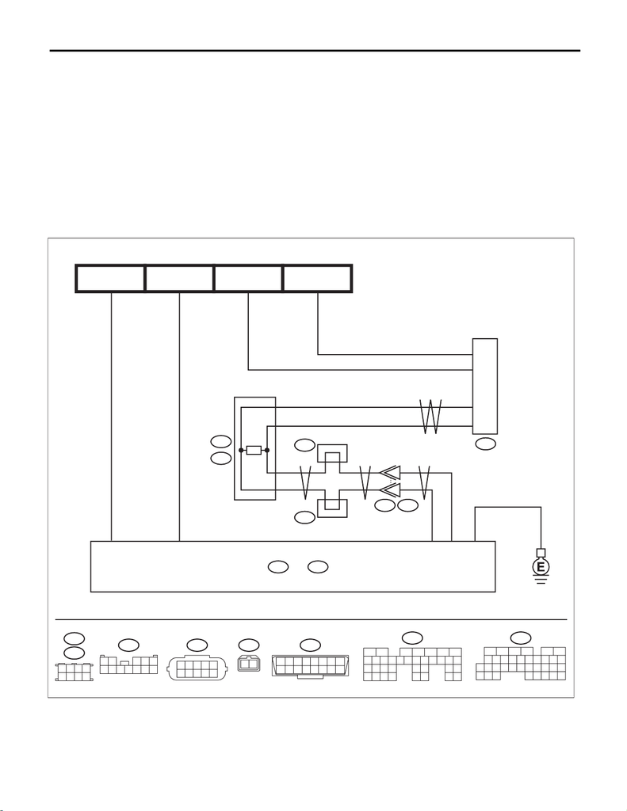

PS(diag)-33

Diagnostic Procedure with Diagnostic Trouble Code (DTC)

POWER ASSISTED SYSTEM (POWER STEERING) (DIAGNOSTICS)

M: DTC C2551 POWER SUPPLY RELAY FAILURE

DTC DETECTING CONDITION:

• When contact deposit malfunction of power supply relay is detected at initial check.

• When power supply voltage failure is detected after the ignition switch is ON.

• When power supply voltage drop is detected with 500 rpm engine speed reception.

TROUBLE SYMPTOM:

• The steering wheel operation feels heavy.

• STEERING warning light illuminates.

NOTE:

If power supply voltage failure exists at the vehicle side, the warning light goes off if the normal voltage re-

turns.

WIRING DIAGRAM:

Electric power steering system <Ref. to WI-159, Electric Power Steering System.>

A:

B:

B452

12

B450

9

10

78

5

6

34

2

1

B40

1

9

8

16

2

10

7

15

3

11

6

14

4

12

5

13

B:

B281

29

10 11 12 13 14 15

16

30

98

17 18 19

20

28

21 22 23

3231

26 27

33 34 35

i229

12 345

6789

10 11 12

i233

78

5

6

34

21

i232

C:

i84

19

18

21

20

17

1234

56

27

28 29 30

31 32 33 34 35

798

J/C

i233

J/C

i232

C27

I/F

7

6

C35

B28

B20

C: i84

B551i229

8

B1

6

14

A7

A6

A1

B2

B40

B452

BA:

B450

16

PS-01705

:

BAT-1

(B)

POWER STEERING CM

DATA LINK

CONNECTOR

MB-27

M/B FUSE NO. 13

(B)

FB-44

F/B FUSE NO. 33

(IG)

FB-32

F/B FUSE NO. 4

(IG)

BODY INTEGRATED

UNIT

[figure not shown]

PS(diag)-34

Diagnostic Procedure with Diagnostic Trouble Code (DTC)

POWER ASSISTED SYSTEM (POWER STEERING) (DIAGNOSTICS)

Step Check Yes No

1 CHECK BATTERY AND FUSE.

Check the battery and fuse.

Is the voltage 12 V or more?

Is the specific gravity 1.260 or

more?

Is the battery terminal installed

properly?

Is the fuse OK?

Go to step 2. Repair or replace

faulty parts.

2 CHECK WIRING HARNESS.

1) Disconnect the connector of the power

steering control module.

2) Turn the ignition switch to ON.

3) Using a tester and test harness, check the

voltage between terminals.

Connector & terminal

(B452) No. 2 (+) — Chassis ground (–):

Is the voltage 12 V or more? Go to step 3. Repair the open

circuit of harness

or the poor contact

of connector

between the power

steering control

module and the

battery.

3 CHECK GROUND CIRCUIT.

1) Turn the ignition switch to OFF.

2) Using a tester and test harness, check the

resistance between terminals.

Connector & terminal

(B452) No. 1 — Chassis ground:

Is the resistance less than 1 Ω? Check for poor

contact of termi-

nals in the power

steering control

module, and if

there are no mal-

functions, replace

the power steering

control module.

<Ref. to PS-84,

Power Steering

Control Module.>

Repair the open

circuit or poor con-

tact of the harness

between the power

steering control

module and chas-

sis ground.

PS(diag)-35

Diagnostic Procedure with Diagnostic Trouble Code (DTC)

POWER ASSISTED SYSTEM (POWER STEERING) (DIAGNOSTICS)

N: DTC U0073 CONTROL MODULE COMMUNICATION BUS OFF

NOTE:

Refer to “LAN SYSTEM (DIAGNOSTICS)” for diagnostic procedure. <Ref. to LAN(diag)-2, Basic Diagnostic

Procedure.>

O: DTC U0100 LOST COMMUNICATION WITH ECM/PCM “A”

NOTE:

Refer to “LAN SYSTEM (DIAGNOSTICS)” for diagnostic procedure. <Ref. to LAN(diag)-2, Basic Diagnostic

Procedure.>

P: DTC U0122 LOST COMMUNICATION WITH VEHICLE DYNAMICS CONTROL

MODULE

NOTE:

Refer to “LAN SYSTEM (DIAGNOSTICS)” for diagnostic procedures. <Ref. to LAN(diag)-2, Basic Diagnostic

Procedure.>

Q: DTC U0126 LOST COMMUNICATION WITH STEERING ANGLE SENSOR

MODULE

NOTE:

Refer to “LAN SYSTEM (DIAGNOSTICS)” for diagnostic procedure. <Ref. to LAN(diag)-2, Basic Diagnostic

Procedure.>

R: DTC U0155 LOST COMMUNICATION WITH INSTRUMENT PANEL CLUSTER

(IPC) CONTROL MODULE

NOTE:

Refer to “LAN SYSTEM (DIAGNOSTICS)” for diagnostic procedure. <Ref. to LAN(diag)-2, Basic Diagnostic

Procedure.>

S: DTC U0401 INVALID DATA RECEIVED FROM ECM/PCM “A”

NOTE:

Refer to “LAN SYSTEM (DIAGNOSTICS)” for diagnostic procedure. <Ref. to LAN(diag)-2, Basic Diagnostic

Procedure.>

T: DTC U0416 INVALID DATA RECEIVED FROM VEHICLE DYNAMICS CON-

TROL MODULE

NOTE:

Refer to “LAN SYSTEM (DIAGNOSTICS)” for diagnostic procedures. <Ref. to LAN(diag)-2, Basic Diagnostic

Procedure.>

PS(diag)-36

Diagnostic Procedure with Diagnostic Trouble Code (DTC)

POWER ASSISTED SYSTEM (POWER STEERING) (DIAGNOSTICS)

[figure not shown]

2015 WRX / WRX STI SERVICE MANUAL QUICK REFERENCE INDEX

FUJI HEAVY INDUSTRIES LTD. G1190BE6

BODY SECTION

This service manual has been prepared

to provide SUBARU service personnel

with the necessary information and data

for the correct maintenance and repair

of SUBARU vehicles.

This manual includes the procedures

for maintenance, disassembling, reas-

sembling, inspection and adjustment of

components and diagnostics for guid-

ance of experienced mechanics.

Please peruse and utilize this manual

fully to ensure complete repair work for

satisfying our customers by keeping

their vehicle in optimum condition.

When replacement of parts during

repair work is needed, be sure to use

SUBARU genuine parts.

All information, illustration and specifi-

cations contained in this manual are

based on the latest product information

available at the time of publication

approval.

HVAC SYSTEM

(HEATER, VENTILATOR AND A/C)

AC

HVAC SYSTEM (AUTO A/C)

(DIAGNOSTICS)

AC(diag)

AIRBAG SYSTEM AB

AIRBAG SYSTEM (DIAGNOSTICS) AB(diag)

OCCUPANT DETECTION SYSTEM

(DIAGNOSTICS)

OD(diag)

SEAT BELT SYSTEM SB

LIGHTING SYSTEM LI

AUTO HEADLIGHT BEAM LEVELER

SYSTEM (DIAGNOSTICS)

AL(diag)

WIPER AND WASHER SYSTEMS WW

ENTERTAINMENT ET

COMMUNICATION SYSTEM COM

GLASS/WINDOWS/MIRRORS GW

BODY STRUCTURE BS

INSTRUMENTATION/DRIVER INFO IDI

INSTRUMENTATION/DRIVER INFO

(DIAGNOSTICS)

IDI(diag)

SEATS SE

SECURITY AND LOCKS SL

[figure not shown]

2015 WRX / WRX STI SERVICE MANUAL QUICK REFERENCE INDEX

G1190BE6

BODY SECTION

SUNROOF/T-TOP/CONVERTIBLE TOP

(SUNROOF)

SR

EXTERIOR/INTERIOR TRIM EI

EXTERIOR BODY PANELS EB

CRUISE CONTROL SYSTEM CC

CRUISE CONTROL SYSTEM

(DIAGNOSTICS)

CC(diag)

IMMOBILIZER (DIAGNOSTICS) IM(diag)

LAN SYSTEM (DIAGNOSTICS) LAN(diag)

KEYLESS ACCESS WITH PUSH BUTTON

START SYSTEM (DIAGNOSTICS)

KPS(diag)

BODY CONTROL SYSTEM (DIAGNOSTICS) BC(diag)

[figure not shown]

HVAC SYSTEM (HEATER, VENTILATOR

AND A/C)

AC

Page

1. General Description ...................................................................................2

2. Air Conditioning System ...........................................................................21

3. Refrigerant Pressure with Manifold Gauge Set ........................................22

4. Refrigerant Recovery Procedure ..............................................................26

5. Refrigerant Charging Procedure ..............................................................27

6. Refrigerant Leak Check ...........................................................................30

7. Relay and Fuse ........................................................................................32

8. Compressor Oil ........................................................................................34

9. Blower Motor Unit Assembly ....................................................................35

10. Blower Motor ............................................................................................37

11. Power Transistor (Auto A/C Model) .........................................................38

12. Heater Core ..............................................................................................40

13. Control Panel ...........................................................................................44

14. Compressor ..............................................................................................45

15. Condenser ................................................................................................50

16. Heater and Cooling Unit ...........................................................................54

17. Evaporator ................................................................................................57

18. Expansion Valve ......................................................................................61

19. Hose and Pipe ..........................................................................................63

20. Pressure Switch (Triple Pressure Switch) ................................................71

21. Ambient Sensor ........................................................................................72

22. Sunload Sensor (Auto A/C Model) ...........................................................75

23. In-Vehicle Sensor (Auto A/C Model) ........................................................77

24. Evaporator Sensor ...................................................................................80

25. FRESH/RECIRC Door Actuator ...............................................................84

26. Mode Door Actuator .................................................................................86

27. Air Mix Door Actuator ...............................................................................88

28. Air Vent Grille ...........................................................................................91

29. Heater Duct ..............................................................................................93

30. Heater Vent Duct ......................................................................................94

31. A/C Filter ..................................................................................................95

32. Diagnostics with Phenomenon .................................................................96